# INSPIRE, GO, and Pfam Petal Similarity Analysis

Gurkan Bebek

July 29, 2026

```r
required_cran <- c(
  "DBI", "RSQLite", "dplyr", "tidyr", "readr", "stringr",
  "ggplot2", "igraph", "pheatmap", "patchwork"
)

missing_cran <- required_cran[!vapply(required_cran, requireNamespace, logical(1), quietly = TRUE)]
if (length(missing_cran) > 0) {
  stop(
    "Install missing R packages before knitting: ",
    paste(missing_cran, collapse = ", "),
    "\nExample: install.packages(c(",
    paste(sprintf("'%s'", missing_cran), collapse = ", "),
    "))"
  )
}

library(DBI)
library(RSQLite)
library(dplyr)
library(tidyr)
library(readr)
library(stringr)
library(ggplot2)
library(igraph)
library(pheatmap)
library(patchwork)

set.seed(params$random_seed)
dir.create(params$output_dir, recursive = TRUE, showWarnings = FALSE)

fmt <- function(x, digits = 3) format(round(x, digits), nsmall = digits)
```

# 1 Purpose and analysis design

This report compares the petal networks in three distinct ways:

1. **INSPIRE network similarity**: the normalized score produced by the network-alignment algorithm implemented in C++.
2. **GO gene-set similarity**: petal genes are compared directly using the gene-pair GO scores. Network topology is not used.
3. **Pfam gene-set similarity**: petal genes are compared directly using Jaccard similarity between their Pfam-domain sets. Network topology is not used.

GO-only and Pfam-only are therefore independent petal gene-set comparisons.

For GO and Pfam, petal-level similarity is calculated with the symmetric best-match average (BMA):

$$S(A,B) = \frac{1}{2}\left[
\frac{1}{|A|}\sum_{a \in A}\max_{b \in B}s(a,b)
+
\frac{1}{|B|}\sum_{b \in B}\max_{a \in A}s(a,b)
\right]$$

This statistic gives every gene in each petal one best counterpart in the other petal, treats the two petals symmetrically, and accommodates unequal petal sizes. The diagonal is defined as 1 for all three matrices.

The primary clustering uses the complete similarity matrices. The threshold of 0.6 is used only for a high-confidence INSPIRE graph and sensitivity summaries, not to manufacture the primary clusters.

# 2 Load and validate the SQLite database

```r
db_file <- normalizePath(params$database, mustWork = TRUE)

cat("DB:", db_file, "\n")
```

```
## DB: /Users/gurkan/Box/Research/INSPIRE/inspire-replication/database/inspire.sqlite
```

```r
con <- dbConnect(RSQLite::SQLite(), db_file)

cat("Connected\n")
```

```
## Connected
```

```r
cat("Valid:", DBI::dbIsValid(con), "\n")
```

```
## Valid: TRUE
```

```r
print(DBI::dbListTables(con))
```

```
##  [1] "annotation_status"     "edge"                  "edge_observation"
##  [4] "gene"                  "gene_uniprot"          "go_pair_score"
##  [7] "go_parent"             "go_term"               "go_term_gene_count"
## [10] "import_problem"        "metadata"              "petal"
## [13] "petal_gene"            "protein_go_annotation" "protein_pfam"
```

```r
integrity <- dbGetQuery(con, "PRAGMA integrity_check")[[1]][1]
```

```r
cat("START DATABASE CHUNK\n")
```

```
## START DATABASE CHUNK
```

```r
print(exists("con"))
```

```
## [1] TRUE
```

```r
if (exists("con")) {
  print(con)
}
```

```
## <SQLiteConnection>
##   Path: /Users/gurkan/Box/Research/INSPIRE/inspire-replication/database/inspire.sqlite
##   Extensions: TRUE
```

```r
db_file <- normalizePath(params$database, mustWork = TRUE)

con <- DBI::dbConnect(RSQLite::SQLite(), db_file)


integrity <- dbGetQuery(con, "PRAGMA integrity_check")[[1]][1]
if (!identical(integrity, "ok")) stop("SQLite integrity check failed: ", integrity)

fk <- dbGetQuery(con, "PRAGMA foreign_key_check")
if (nrow(fk) > 0) stop("SQLite foreign-key check returned errors")

petals <- dbGetQuery(
  con,
  "SELECT petal, gene_count, edge_count FROM petal ORDER BY petal"
)

petal_names <- petals$petal
n_petals <- length(petal_names)
if (n_petals < 3) stop("At least three petals are required for clustering")

petals
```

```
##      petal gene_count edge_count
## 1    ABCA1          6          6
## 2     BCL9          4          3
## 3    ERCC6          7          8
## 4    FBXW7         27         52
## 5      FN1         10         15
## 6     GLI3          6          7
## 7   IGFBP3          4          3
## 8     KRAS         23         44
## 9    MAP1B          4          3
## 10  MCM3AP          4          3
## 11    MMP2          5          5
## 12    NAV3          4          3
## 13     NF1         13         20
## 14  PIK3CA         25         46
## 15   PLCG2          4          3
## 16   PRKD1          7          8
## 17    PTEN         43         94
## 18 RUNX1T1          4          3
## 19   SMAD2         44         94
## 20   SMAD3         18         29
## 21   SMAD4         25         48
## 22    TAF2          6          6
## 23  TCF7L2         11         17
## 24  TGFBR2         20         32
## 25   TIAM1          6          7
## 26   UHRF2          5          5
## 27  ZNF521          4          3
```

# 3 Helper functions

```r
empty_similarity_matrix <- function(names) {
  m <- matrix(NA_real_, nrow = length(names), ncol = length(names),
              dimnames = list(names, names))
  diag(m) <- 1
  m
}

long_pairs_to_matrix <- function(df, names, value_col = "score") {
  m <- empty_similarity_matrix(names)
  values <- df[[value_col]]
  for (i in seq_len(nrow(df))) {
    a <- df$petal_a[i]
    b <- df$petal_b[i]
    if (a %in% names && b %in% names && is.finite(values[i])) {
      m[a, b] <- values[i]
      m[b, a] <- values[i]
    }
  }
  diag(m) <- 1
  m
}

validate_similarity <- function(m, label) {
  if (!is.matrix(m) || nrow(m) != ncol(m)) stop(label, " is not square")
  if (!identical(rownames(m), colnames(m))) stop(label, " names do not match")
  if (anyNA(m)) {
    missing <- which(is.na(m), arr.ind = TRUE)
    stop(label, " contains missing values; first missing pair: ",
         rownames(m)[missing[1, 1]], " / ", colnames(m)[missing[1, 2]])
  }
  if (max(abs(m - t(m))) > 1e-10) stop(label, " is not symmetric")
  if (any(m < -1e-10 | m > 1 + 1e-10)) {
    stop(label, " contains values outside [0, 1]")
  }
  invisible(TRUE)
}

best_match_average <- function(genes_a, genes_b, gene_similarity) {
  block <- gene_similarity[genes_a, genes_b, drop = FALSE]
  if (length(block) == 0 || anyNA(block)) return(NA_real_)
  forward <- mean(apply(block, 1, max))
  reverse <- mean(apply(block, 2, max))
  (forward + reverse) / 2
}

matrix_to_long <- function(m, method) {
  as.data.frame(as.table(m), stringsAsFactors = FALSE) |>
    transmute(petal_a = Var1, petal_b = Var2, score = Freq, method = method) |>
    filter(petal_a < petal_b)
}

similarity_heatmap <- function(m, title, annotation = NULL) {
  pheatmap(
    m,
    clustering_distance_rows = as.dist(1 - m),
    clustering_distance_cols = as.dist(1 - m),
    clustering_method = "average",
    annotation_row = annotation,
    annotation_col = annotation,
    main = title,
    border_color = NA,
    silent = TRUE
  )
}

# Item-resampling consensus hierarchical clustering for a precomputed
# similarity matrix. At each iteration, a subset of petals is clustered using
# D = 1 - S. Co-clustering counts are divided by co-sampling counts.
consensus_for_k <- function(similarity, k, reps = 1000, item_fraction = 0.8,
                            linkage = "average", seed = 1) {
  set.seed(seed + k)
  n <- nrow(similarity)
  item_count <- max(k + 1L, ceiling(n * item_fraction))
  item_count <- min(item_count, n)

  sampled_count <- matrix(0L, n, n, dimnames = dimnames(similarity))
  cocluster_count <- matrix(0L, n, n, dimnames = dimnames(similarity))

  for (r in seq_len(reps)) {
    idx <- sort(sample.int(n, item_count, replace = FALSE))
    sub_similarity <- similarity[idx, idx, drop = FALSE]
    hc <- hclust(as.dist(1 - sub_similarity), method = linkage)
    membership <- cutree(hc, k = k)

    sampled_count[idx, idx] <- sampled_count[idx, idx] + 1L
    same_cluster <- outer(membership, membership, FUN = "==")
    cocluster_count[idx, idx] <- cocluster_count[idx, idx] + same_cluster
  }

  consensus <- matrix(NA_real_, n, n, dimnames = dimnames(similarity))
  observed <- sampled_count > 0
  consensus[observed] <- cocluster_count[observed] / sampled_count[observed]
  diag(consensus) <- 1

  hc_final <- hclust(as.dist(1 - consensus), method = linkage)
  clusters <- cutree(hc_final, k = k)

  off_diagonal <- consensus[upper.tri(consensus)]
  pac <- mean(off_diagonal > 0.1 & off_diagonal < 0.9, na.rm = TRUE)

  within <- c()
  for (cluster_id in sort(unique(clusters))) {
    members <- which(clusters == cluster_id)
    if (length(members) >= 2) {
      within <- c(within, consensus[members, members][upper.tri(consensus[members, members])])
    }
  }

  list(
    k = k,
    consensus = consensus,
    clusters = clusters,
    pac = pac,
    mean_within_consensus = if (length(within)) mean(within, na.rm = TRUE) else NA_real_
  )
}

run_consensus <- function(similarity, max_k, reps, item_fraction, seed) {
  max_k <- min(max_k, nrow(similarity) - 1L)
  results <- lapply(2:max_k, function(k) {
    consensus_for_k(similarity, k, reps, item_fraction, seed = seed)
  })
  metrics <- bind_rows(lapply(results, function(x) {
    tibble(k = x$k, PAC = x$pac,
           mean_within_consensus = x$mean_within_consensus)
  }))
  # Lower PAC is preferred. Ties are resolved in favor of the smaller k.
  best_k <- metrics$k[order(metrics$PAC, metrics$k)][1]
  best <- results[[which(vapply(results, function(x) x$k, integer(1)) == best_k)]]
  list(results = results, metrics = metrics, best = best)
}
```

# 4 Comparison 1: INSPIRE network similarity

## 4.1 Parse completed all-versus-all logs

```r
stopifnot(dir.exists(params$inspire_log_dir))
log_files <- list.files(params$inspire_log_dir, pattern = "\\.log$", full.names = TRUE)
if (length(log_files) == 0) stop("No INSPIRE log files were found")

parse_inspire_log <- function(path) {
  text <- paste(readLines(path, warn = FALSE), collapse = "\n")
  matches <- str_match_all(
    text,
    "\\$RESULT\\$\\s+(\\S+)\\s+(\\S+)\\s+norm_score:\\s+(-?[0-9.]+(?:[eE][+-]?[0-9]+)?)"
  )[[1]]

  if (nrow(matches) == 0) {
    return(tibble(log_file = path, petal_a = NA_character_, petal_b = NA_character_,
                  score = NA_real_, status = "incomplete"))
  }

  last <- matches[nrow(matches), ]
  tibble(
    log_file = path,
    petal_a = last[2],
    petal_b = last[3],
    score = as.numeric(last[4]),
    status = "complete"
  )
}

inspire_logs <- bind_rows(lapply(log_files, parse_inspire_log))
inspire_pairs <- inspire_logs |>
  filter(status == "complete", petal_a != petal_b) |>
  distinct(petal_a, petal_b, .keep_all = TRUE)

expected_off_diagonal <- n_petals * (n_petals - 1) / 2
if (nrow(inspire_pairs) != expected_off_diagonal) {
  warning(
    "Expected ", expected_off_diagonal, " completed off-diagonal INSPIRE pairs, found ",
    nrow(inspire_pairs), ". The matrix validation below will identify missing pairs."
  )
}

inspire_similarity <- long_pairs_to_matrix(inspire_pairs, petal_names)
validate_similarity(inspire_similarity, "INSPIRE similarity")

write.csv(
  inspire_similarity,
  file.path(params$output_dir, "similarity_inspire.csv"),
  quote = FALSE
)
```

## 4.2 INSPIRE distribution and high-confidence graph

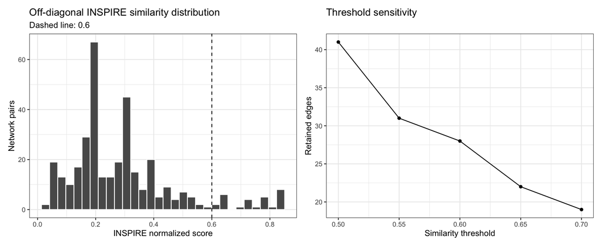

```r
inspire_long <- matrix_to_long(inspire_similarity, "INSPIRE")

p_hist <- ggplot(inspire_long, aes(score)) +
  geom_histogram(bins = 30, color = "white") +
  geom_vline(xintercept = params$inspire_threshold, linetype = 2) +
  labs(
    title = "Off-diagonal INSPIRE similarity distribution",
    subtitle = paste("Dashed line:", params$inspire_threshold),
    x = "INSPIRE normalized score",
    y = "Network pairs"
  ) +
  theme_bw()

threshold_summary <- tibble(threshold = seq(0.50, 0.70, by = 0.05)) |>
  rowwise() |>
  mutate(
    retained_edges = sum(inspire_long$score > threshold),
    retained_fraction = retained_edges / nrow(inspire_long)
  ) |>
  ungroup()

p_threshold <- ggplot(threshold_summary, aes(threshold, retained_edges)) +
  geom_line() +
  geom_point() +
  labs(
    title = "Threshold sensitivity",
    x = "Similarity threshold",
    y = "Retained edges"
  ) +
  theme_bw()

p_hist + p_threshold
```

```r
high_edges <- inspire_long |>
  filter(score > params$inspire_threshold) |>
  select(from = petal_a, to = petal_b, weight = score)

inspire_graph <- graph_from_data_frame(
  high_edges,
  directed = FALSE,
  vertices = tibble(name = petal_names)
)

components_table <- tibble(
  petal = names(components(inspire_graph)$membership),
  component = unname(components(inspire_graph)$membership)
) |>
  group_by(component) |>
  mutate(component_size = n()) |>
  ungroup() |>
  arrange(desc(component_size), component, petal)

write_csv(
  components_table,
  file.path(params$output_dir, "inspire_threshold_components.csv")
)

components_table
```

```
## # A tibble: 27 × 3
##    petal  component component_size
##    <chr>      <dbl>          <int>
##  1 ABCA1          1             14
##  2 FBXW7          1             14
##  3 FN1            1             14
##  4 KRAS           1             14
##  5 MMP2           1             14
##  6 NF1            1             14
##  7 PIK3CA         1             14
##  8 PLCG2          1             14
##  9 PTEN           1             14
## 10 SMAD2          1             14
## # ℹ 17 more rows
```

# 5 Comparison 2: GO gene-set similarity

GO gene-pair scores are read from `go_pair_score` for the selected algorithm. Scores are normalized by the maximum score for that algorithm so the gene-level values lie in `[0,1]`. Petal-level GO similarity is then calculated by symmetric BMA over the petal gene sets.

```r
gene_map <- dbGetQuery(
  con,
  "SELECT gene_symbol, uniprot_accession FROM gene_uniprot WHERE is_preferred = 1"
)

petal_genes <- dbGetQuery(
  con,
  "SELECT petal, gene_symbol FROM petal_gene ORDER BY petal, gene_symbol"
)

all_genes <- sort(unique(petal_genes$gene_symbol))
if (!all(all_genes %in% gene_map$gene_symbol)) stop("A petal gene lacks a preferred UniProt mapping")

protein_to_gene <- setNames(gene_map$gene_symbol, gene_map$uniprot_accession)

go_rows <- dbGetQuery(
  con,
  "SELECT protein1, protein2, score FROM go_pair_score WHERE algorithm = ?",
  params = list(params$go_algorithm)
)
if (nrow(go_rows) == 0) stop("No GO scores found for algorithm: ", params$go_algorithm)

go_max <- max(go_rows$score, na.rm = TRUE)
if (!is.finite(go_max) || go_max <= 0) stop("Invalid maximum GO score")

gene_go <- matrix(NA_real_, length(all_genes), length(all_genes),
                  dimnames = list(all_genes, all_genes))

for (i in seq_len(nrow(go_rows))) {
  g1 <- unname(protein_to_gene[go_rows$protein1[i]])
  g2 <- unname(protein_to_gene[go_rows$protein2[i]])
  if (!is.na(g1) && !is.na(g2) && g1 %in% all_genes && g2 %in% all_genes) {
    value <- go_rows$score[i] / go_max
    gene_go[g1, g2] <- value
    gene_go[g2, g1] <- value
  }
}
diag(gene_go) <- 1
if (anyNA(gene_go)) stop("The GO gene-similarity matrix is incomplete")

petal_gene_list <- split(petal_genes$gene_symbol, petal_genes$petal)
go_similarity <- empty_similarity_matrix(petal_names)

for (i in seq_along(petal_names)) {
  for (j in i:length(petal_names)) {
    a <- petal_names[i]
    b <- petal_names[j]
    score <- if (a == b) 1 else best_match_average(
      petal_gene_list[[a]], petal_gene_list[[b]], gene_go
    )
    go_similarity[a, b] <- score
    go_similarity[b, a] <- score
  }
}

validate_similarity(go_similarity, "GO BMA similarity")
write.csv(go_similarity, file.path(params$output_dir, "similarity_go_bma.csv"), quote = FALSE)
```

# 6 Comparison 3: Pfam gene-set similarity

For every pair of genes, Pfam similarity is Jaccard similarity between the two sets of unique Pfam accessions:

$$J(A,B) = \frac{|A \cap B|}{|A \cup B|}$$

If both proteins have no Pfam annotations, the pair receives zero rather than being treated as identical. Petal-level Pfam similarity is then calculated with symmetric BMA.

```r
pfam_rows <- dbGetQuery(
  con,
  "SELECT uniprot_accession, pfam_accession FROM protein_pfam ORDER BY uniprot_accession, pfam_accession"
)

pfam_by_protein <- split(pfam_rows$pfam_accession, pfam_rows$uniprot_accession)
gene_to_protein <- setNames(gene_map$uniprot_accession, gene_map$gene_symbol)

pfam_jaccard <- function(gene_a, gene_b) {
  protein_a <- unname(gene_to_protein[gene_a])
  protein_b <- unname(gene_to_protein[gene_b])
  a <- unique(pfam_by_protein[[protein_a]])
  b <- unique(pfam_by_protein[[protein_b]])
  if (is.null(a)) a <- character()
  if (is.null(b)) b <- character()
  union_size <- length(union(a, b))
  if (union_size == 0) return(0)
  length(intersect(a, b)) / union_size
}

gene_pfam <- matrix(0, length(all_genes), length(all_genes),
                    dimnames = list(all_genes, all_genes))
for (i in seq_along(all_genes)) {
  for (j in i:length(all_genes)) {
    value <- if (i == j) 1 else pfam_jaccard(all_genes[i], all_genes[j])
    gene_pfam[i, j] <- value
    gene_pfam[j, i] <- value
  }
}

pfam_similarity <- empty_similarity_matrix(petal_names)
for (i in seq_along(petal_names)) {
  for (j in i:length(petal_names)) {
    a <- petal_names[i]
    b <- petal_names[j]
    score <- if (a == b) 1 else best_match_average(
      petal_gene_list[[a]], petal_gene_list[[b]], gene_pfam
    )
    pfam_similarity[a, b] <- score
    pfam_similarity[b, a] <- score
  }
}

validate_similarity(pfam_similarity, "Pfam BMA similarity")
write.csv(pfam_similarity, file.path(params$output_dir, "similarity_pfam_bma.csv"), quote = FALSE)
```

# 7 Compare the three similarity distributions

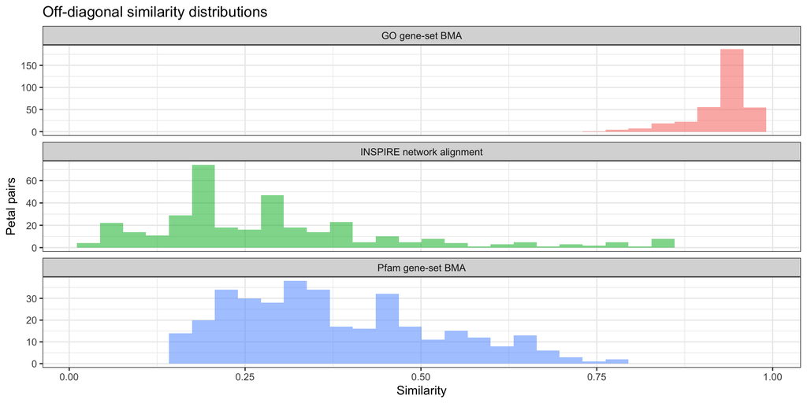

```r
all_long <- bind_rows(
  matrix_to_long(inspire_similarity, "INSPIRE network alignment"),
  matrix_to_long(go_similarity, "GO gene-set BMA"),
  matrix_to_long(pfam_similarity, "Pfam gene-set BMA")
)

write_csv(all_long, file.path(params$output_dir, "all_similarity_pairs_long.csv"))

ggplot(all_long, aes(score, fill = method)) +
  geom_histogram(bins = 30, alpha = 0.55, position = "identity") +
  facet_wrap(~method, ncol = 1, scales = "free_y") +
  labs(x = "Similarity", y = "Petal pairs", title = "Off-diagonal similarity distributions") +
  theme_bw() +
  theme(legend.position = "none")
```

```r
score_wide <- all_long |>
  select(petal_a, petal_b, method, score) |>
  pivot_wider(names_from = method, values_from = score)

pearson_correlations <- cor(
  score_wide |> select(where(is.numeric)),
  method = "pearson"
)

spearman_correlations <- cor(
  score_wide |> select(where(is.numeric)),
  method = "spearman"
)

pearson_correlations
```

```
##                           INSPIRE network alignment GO gene-set BMA
## INSPIRE network alignment                 1.0000000       0.6405222
## GO gene-set BMA                           0.6405222       1.0000000
## Pfam gene-set BMA                         0.7727605       0.5233587
##                           Pfam gene-set BMA
## INSPIRE network alignment         0.7727605
## GO gene-set BMA                   0.5233587
## Pfam gene-set BMA                 1.0000000
```

```r
spearman_correlations
```

```
##                           INSPIRE network alignment GO gene-set BMA
## INSPIRE network alignment                 1.0000000       0.8458777
## GO gene-set BMA                           0.8458777       1.0000000
## Pfam gene-set BMA                         0.7855987       0.7263128
##                           Pfam gene-set BMA
## INSPIRE network alignment         0.7855987
## GO gene-set BMA                   0.7263128
## Pfam gene-set BMA                 1.0000000
```

```r
write.csv(pearson_correlations, file.path(params$output_dir, "matrix_correlations_pearson.csv"))
write.csv(spearman_correlations, file.path(params$output_dir, "matrix_correlations_spearman.csv"))
```

# 8 Consensus clustering

Consensus clustering is performed independently for each complete similarity matrix. Each iteration samples a fraction of petals, performs average-linkage hierarchical clustering on `1 - similarity`, and records whether co-sampled petals share a cluster. The final consensus matrix is the proportion of co-sampled iterations in which each pair co-clustered.

The number of clusters is explored from 2 through 8. The automatic report selection uses the smallest PAC value, with smaller `k` preferred in a tie. This automatic choice should be reviewed together with the PAC curve, consensus heatmap, cluster sizes, and biological interpretation.

```r
consensus_inspire <- run_consensus(
  inspire_similarity, params$max_k, params$consensus_reps,
  params$consensus_item_fraction, params$random_seed
)
consensus_go <- run_consensus(
  go_similarity, params$max_k, params$consensus_reps,
  params$consensus_item_fraction, params$random_seed + 10000
)
consensus_pfam <- run_consensus(
  pfam_similarity, params$max_k, params$consensus_reps,
  params$consensus_item_fraction, params$random_seed + 20000
)

consensus_metrics <- bind_rows(
  mutate(consensus_inspire$metrics, method = "INSPIRE"),
  mutate(consensus_go$metrics, method = "GO BMA"),
  mutate(consensus_pfam$metrics, method = "Pfam BMA")
)

write_csv(consensus_metrics, file.path(params$output_dir, "consensus_metrics.csv"))
consensus_metrics
```

```
## # A tibble: 21 × 4
##        k    PAC mean_within_consensus method
##    <int>  <dbl>                 <dbl> <chr>
##  1     2 0.205                  0.958 INSPIRE
##  2     3 0.197                  0.956 INSPIRE
##  3     4 0.356                  0.887 INSPIRE
##  4     5 0.387                  0.877 INSPIRE
##  5     6 0.359                  0.860 INSPIRE
##  6     7 0.291                  0.854 INSPIRE
##  7     8 0.242                  0.849 INSPIRE
##  8     2 0.0712                 0.982 GO BMA
##  9     3 0.0684                 0.963 GO BMA
## 10     4 0.128                  0.940 GO BMA
## # ℹ 11 more rows
```

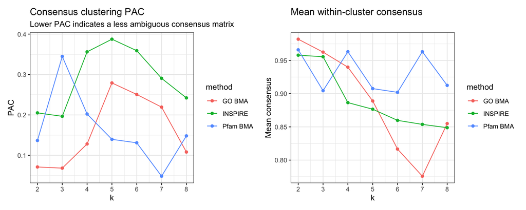

```r
p_pac <- ggplot(consensus_metrics, aes(k, PAC, color = method)) +
  geom_line() + geom_point() +
  scale_x_continuous(breaks = sort(unique(consensus_metrics$k))) +
  labs(title = "Consensus clustering PAC", subtitle = "Lower PAC indicates a less ambiguous consensus matrix") +
  theme_bw()

p_within <- ggplot(consensus_metrics, aes(k, mean_within_consensus, color = method)) +
  geom_line() + geom_point() +
  scale_x_continuous(breaks = sort(unique(consensus_metrics$k))) +
  labs(title = "Mean within-cluster consensus", y = "Mean consensus") +
  theme_bw()

p_pac + p_within
```

# 9 Final cluster assignments

```r
assignments <- tibble(
  petal = petal_names,
  inspire_cluster = unname(consensus_inspire$best$clusters[petal_names]),
  go_cluster = unname(consensus_go$best$clusters[petal_names]),
  pfam_cluster = unname(consensus_pfam$best$clusters[petal_names])
)

selected_k <- tibble(
  method = c("INSPIRE", "GO BMA", "Pfam BMA"),
  selected_k = c(
    consensus_inspire$best$k,
    consensus_go$best$k,
    consensus_pfam$best$k
  ),
  PAC = c(
    consensus_inspire$best$pac,
    consensus_go$best$pac,
    consensus_pfam$best$pac
  )
)

write_csv(assignments, file.path(params$output_dir, "cluster_assignments.csv"))
write_csv(selected_k, file.path(params$output_dir, "selected_cluster_counts.csv"))

selected_k
```

```
## # A tibble: 3 × 3
##   method   selected_k    PAC
##   <chr>         <int>  <dbl>
## 1 INSPIRE           3 0.197
## 2 GO BMA            3 0.0684
## 3 Pfam BMA          7 0.0484
```

```r
assignments
```

```
## # A tibble: 27 × 4
##    petal  inspire_cluster go_cluster pfam_cluster
##    <chr>            <int>      <int>        <int>
##  1 ABCA1                1          1            1
##  2 BCL9                 1          2            1
##  3 ERCC6                1          1            1
##  4 FBXW7                1          1            2
##  5 FN1                  1          1            2
##  6 GLI3                 2          1            3
##  7 IGFBP3               1          1            4
##  8 KRAS                 1          1            2
##  9 MAP1B                1          1            3
## 10 MCM3AP               3          1            5
## # ℹ 17 more rows
```

# 10 Consensus-matrix heatmaps

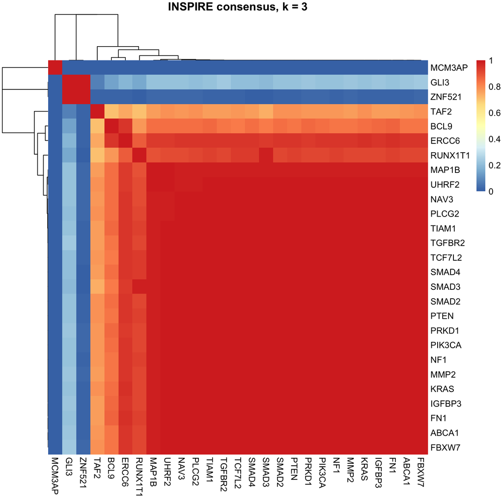

```r
pheatmap(
  consensus_inspire$best$consensus,
  clustering_distance_rows = as.dist(1 - consensus_inspire$best$consensus),
  clustering_distance_cols = as.dist(1 - consensus_inspire$best$consensus),
  main = paste0("INSPIRE consensus, k = ", consensus_inspire$best$k),
  border_color = NA
)
```

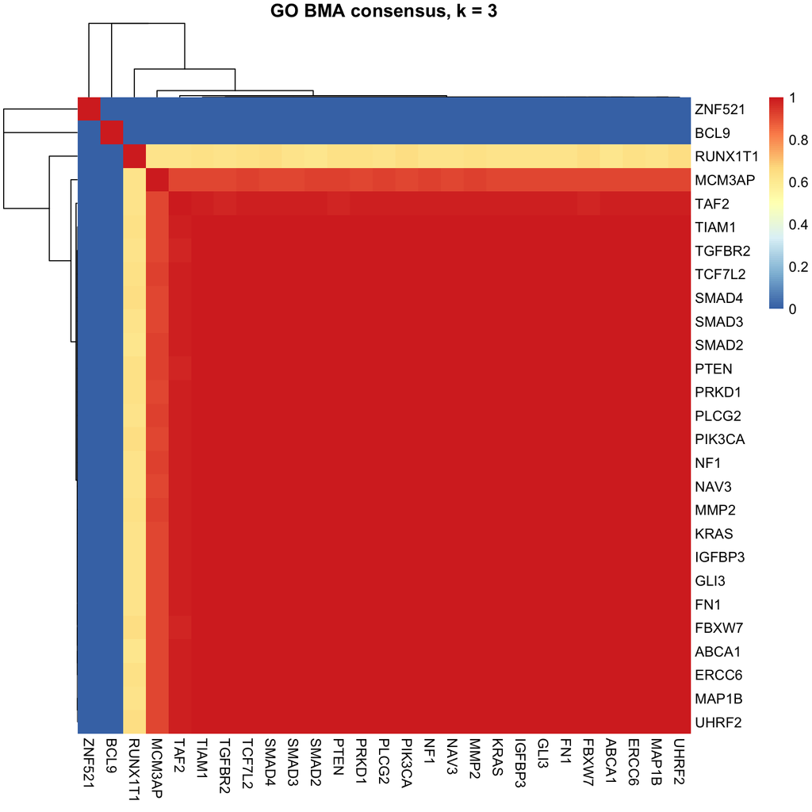

```r
pheatmap(
  consensus_go$best$consensus,
  clustering_distance_rows = as.dist(1 - consensus_go$best$consensus),
  clustering_distance_cols = as.dist(1 - consensus_go$best$consensus),
  main = paste0("GO BMA consensus, k = ", consensus_go$best$k),
  border_color = NA
)
```

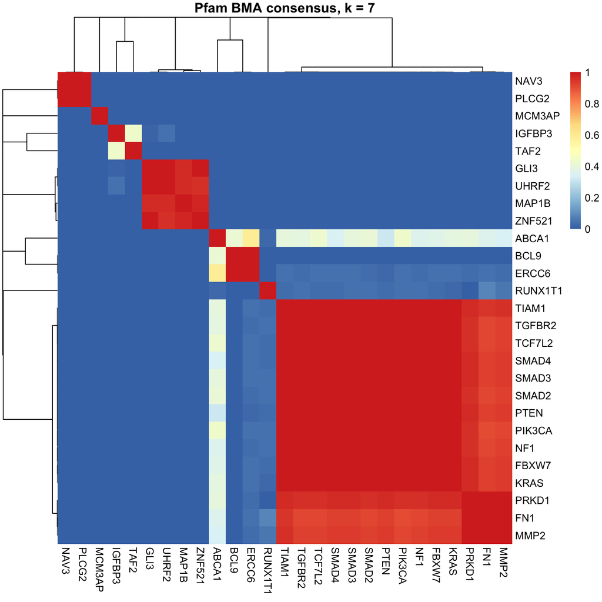

```r
pheatmap(
  consensus_pfam$best$consensus,
  clustering_distance_rows = as.dist(1 - consensus_pfam$best$consensus),
  clustering_distance_cols = as.dist(1 - consensus_pfam$best$consensus),
  main = paste0("Pfam BMA consensus, k = ", consensus_pfam$best$k),
  border_color = NA
)
```

# 11 Side-by-side similarity heatmaps using INSPIRE ordering

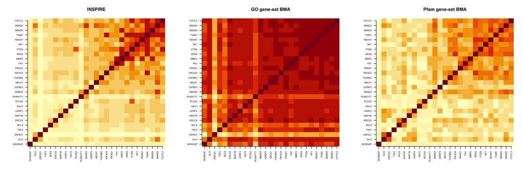

```r
inspire_order <- hclust(as.dist(1 - inspire_similarity), method = "average")$order
ordered_names <- rownames(inspire_similarity)[inspire_order]

annotation <- data.frame(
  INSPIRE = factor(assignments$inspire_cluster),
  GO = factor(assignments$go_cluster),
  Pfam = factor(assignments$pfam_cluster),
  row.names = assignments$petal
)

old_par <- par(no.readonly = TRUE)
par(mfrow = c(1, 3), mar = c(6, 6, 4, 2))
image(
  seq_along(ordered_names), seq_along(ordered_names),
  inspire_similarity[ordered_names, ordered_names],
  axes = FALSE, main = "INSPIRE", xlab = "", ylab = ""
)
axis(1, at = seq_along(ordered_names), labels = ordered_names, las = 2, cex.axis = 0.6)
axis(2, at = seq_along(ordered_names), labels = ordered_names, las = 2, cex.axis = 0.6)
image(
  seq_along(ordered_names), seq_along(ordered_names),
  go_similarity[ordered_names, ordered_names],
  axes = FALSE, main = "GO gene-set BMA", xlab = "", ylab = ""
)
axis(1, at = seq_along(ordered_names), labels = ordered_names, las = 2, cex.axis = 0.6)
axis(2, at = seq_along(ordered_names), labels = ordered_names, las = 2, cex.axis = 0.6)
image(
  seq_along(ordered_names), seq_along(ordered_names),
  pfam_similarity[ordered_names, ordered_names],
  axes = FALSE, main = "Pfam gene-set BMA", xlab = "", ylab = ""
)
axis(1, at = seq_along(ordered_names), labels = ordered_names, las = 2, cex.axis = 0.6)
axis(2, at = seq_along(ordered_names), labels = ordered_names, las = 2, cex.axis = 0.6)
```

```r
par(old_par)
```

# 12 Cluster-agreement summaries

```r
adjusted_rand_index <- function(x, y) {
  tab <- table(x, y)
  choose2 <- function(z) z * (z - 1) / 2
  sum_comb <- sum(choose2(tab))
  row_comb <- sum(choose2(rowSums(tab)))
  col_comb <- sum(choose2(colSums(tab)))
  total_comb <- choose2(sum(tab))
  expected <- row_comb * col_comb / total_comb
  maximum <- (row_comb + col_comb) / 2
  if (maximum == expected) return(1)
  (sum_comb - expected) / (maximum - expected)
}

agreement <- tibble(
  comparison = c("INSPIRE vs GO", "INSPIRE vs Pfam", "GO vs Pfam"),
  adjusted_rand_index = c(
    adjusted_rand_index(assignments$inspire_cluster, assignments$go_cluster),
    adjusted_rand_index(assignments$inspire_cluster, assignments$pfam_cluster),
    adjusted_rand_index(assignments$go_cluster, assignments$pfam_cluster)
  )
)

write_csv(agreement, file.path(params$output_dir, "cluster_agreement_ari.csv"))
agreement
```

```
## # A tibble: 3 × 2
##   comparison      adjusted_rand_index
##   <chr>                         <dbl>
## 1 INSPIRE vs GO                0.314
## 2 INSPIRE vs Pfam              0.161
## 3 GO vs Pfam                   0.0863
```

# 13 Reproducibility information

```r
metadata <- dbGetQuery(
  con,
  "SELECT key, value FROM metadata ORDER BY key"
)
write_csv(metadata, file.path(params$output_dir, "database_metadata.csv"))
metadata
```

```
##                                                       key
## 1                           annotation_loader_last_run_at
## 2                               annotation_loader_version
## 3                                   created_or_updated_at
## 4                                  duplicate_score_policy
## 5                                          edge_direction
## 6                                   go_annotation_version
## 7                                        go_aspect_policy
## 8                                             go_gaf_file
## 9                                        go_gaf_loaded_at
## 10                                          go_gaf_sha256
## 11                                       go_ic_population
## 12                                   go_ic_total_proteins
## 13                                          go_not_policy
## 14                                            go_obo_file
```

[output cut: 71 more lines]

```r
DBI::dbDisconnect(con)
```